# Niche partitioning of bacterial communities in biological soil crusts and subsoil under grasses and trees in the semi-arid Kalahari

> David R Elliott, Andrew D Thomas, Stephen R Hoon, Robin Sen

This html file is generated from source file kalahari_BSC_bacteria.Rmd which is the basis of all analyses presented in the above paper. The .Rmd file can be consulted to find the R commands used in the analyses.

### Summary of Online Resources (supplementary data)

- OR1: Sample metadata and summary statistics, including pyrosequencing barcodes, number of sequences, and richness estimates. This is a tab separated text file based on the sample map used in the QIIME pipeline and other downstream analyses. This file was manually assembled for the paper following reviewer request. It is not automatically generated by this script but all data within it are products of this script.
- OR2: unconstrained correspondence analysis and scree plots
- OR3: ADONIS test results. Text file
- OR4: Zip file containing most of the output from the .Rmd script, but not including this html report

## Data preparation

### Load data from QIIME

```
## phyloseq-class experiment-level object
## otu_table()   OTU Table:         [ 2922 taxa and 48 samples ]
## sample_data() Sample Data:       [ 48 samples by 23 sample variables ]
## tax_table()   Taxonomy Table:    [ 2922 taxa by 7 taxonomic ranks ]
```

Chloroplast and mitochondrial sequences were removed after import (very few reads).

## Pre-process data for each analysis

### Richness / diversity

The full data set was used with original count data and without rarefaction, according to recommendation of the phyloseq and vegan documentation. Rarefaction was used in an earlier version of the analysis. With rarefaction to 437 sequences (excluding 2 samples) the results and statistical tests (see later) followed almost exactly the same profile, although the absolute values changed a bit.

### OTU abundance plots and comparisons

Sequence observations were converted to percentage for each sample, to allow comparison between samples of different sequencing depth.

### Ordination

OTUs accounting for < 0.01% of sequences found in the study were excluded from ordinations.

## Main figures

**Figure 2.** Total carbon and nitrogen in crust and subsoil samples at each site (n=6). Boxes represent the interquartile range (IQR), and error bars extend to the most extreme values within 1.5 * IQR of the box. Median values are shown as a line within the box and outliers are shown as black spots. Sample coding: AG=annual grass, PG=perennial grass, S=shrub, T=tree.

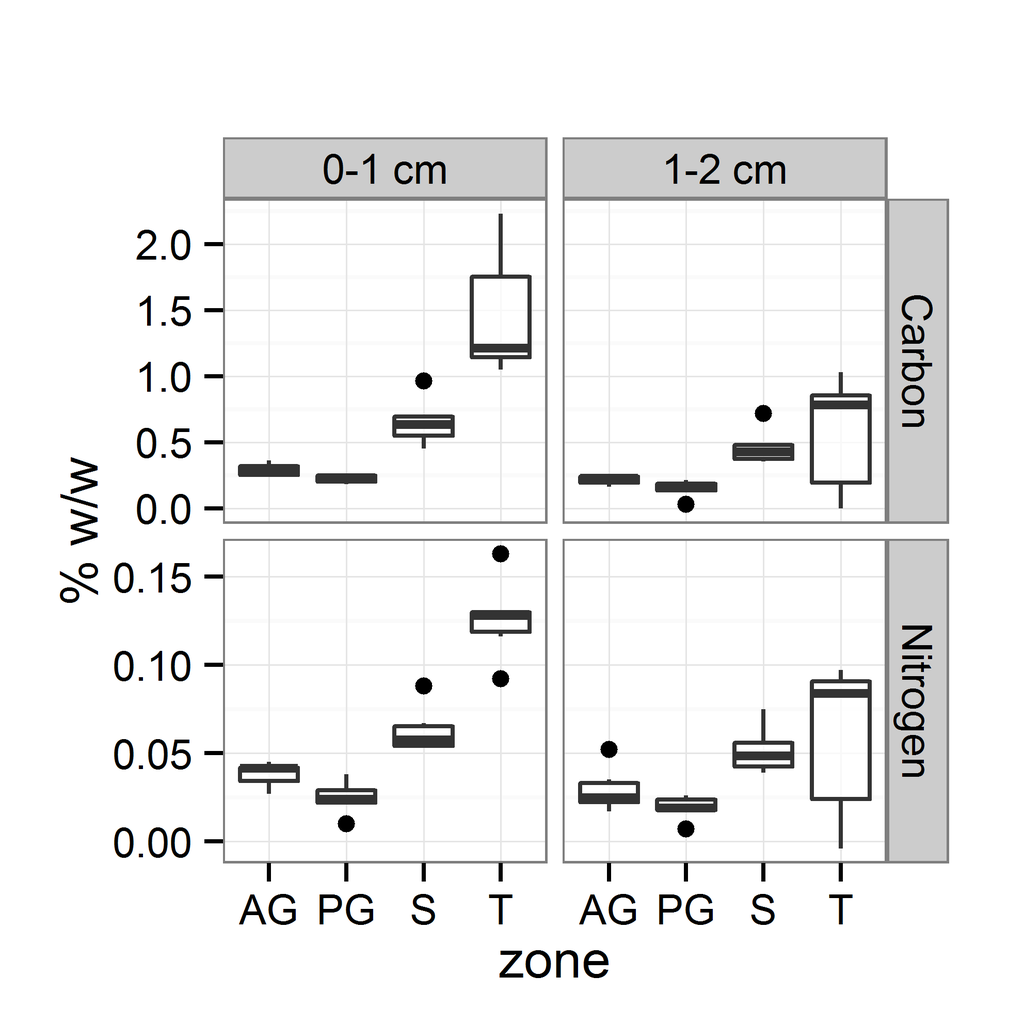

**Figure 3.** OTU richness estimation (Chao1) and diversity index (Shannon) in crust and subsoil. a. Comparison of measures at each site; b. Individual sample richness/diversity with respect to sample carbon content. Boxes represent the interquartile range (IQR), and error bars extend to the most extreme values within 1.5 * IQR of the box. Median values are shown as a line within the box and outliers are shown as black spots. Sample coding: AG=annual grass, PG=perennial grass, S=shrub, T=tree.

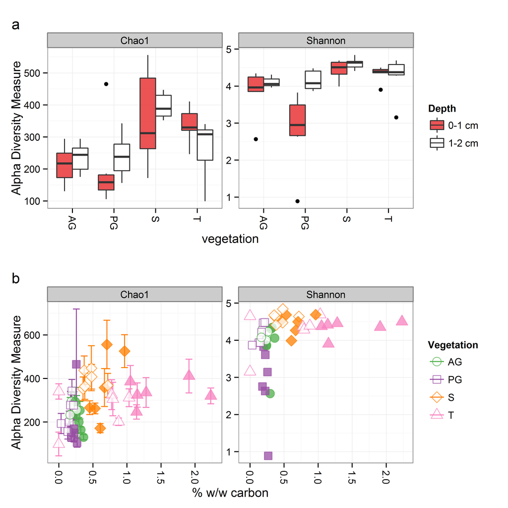

**Figure 4.** Phylum abundance by (a) site and (b) soil carbon content. Boxes represent the interquartile range (IQR), and error bars extend to the most extreme values within 1.5 * IQR of the box. Median values are shown as a line within the box and outliers are shown as black spots. Sample coding: AG=annual grass, PG=perennial grass, S=shrub, T=tree. Significance and direction of correlation between phylum abundance and soil carbon is indicated by + or - (determined by Spearman test). Significance codes for positive correlation: +++ < 0.001; ++ < 0.01; + <0.05. Similar plots for less abundant phyla are included in supplementary data.

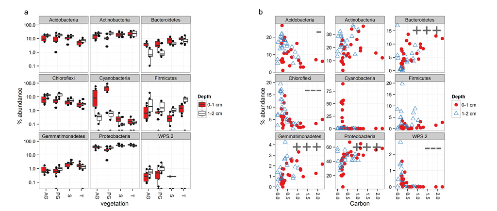

*Figure 5.* Correspondence analysis of the microbial community. Coloured markers indicate individual samples, and dispersion ellipses show the 95 % standard deviation confidence interval for crust/subsoil and canopy/open classifications. OTU identification numbers are shown in different colours for the 9 most abundant OTUs belonging to the followng groups: full dataset (black), phylum Cyanobacteria (green), and phylum Bacteroidetes (blue). Environmental variables with significance p < 0.05, are shown as biplotted vectors (based on permutation tests; n=1000).

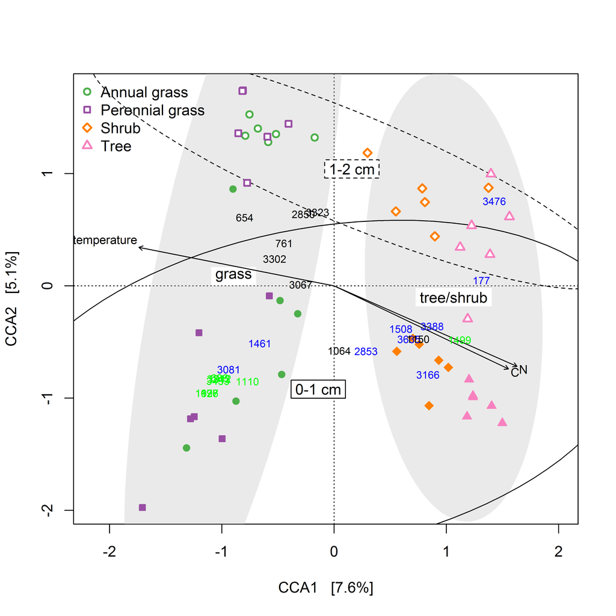

**Figure 6.** Relative abundance of the top 9 OTUs detected in the study, by (a) site and (b) soil carbon content. Boxes represent the interquartile range (IQR), and error bars extend to the most extreme values within 1.5 * IQR of the box. Median values are shown as a line within the box and outliers are shown as black spots. Significance and direction of correlation between OTU abundance and soil carbon is indicated by + or - (determined by Spearman test). Significance codes for positive correlation: +++ < 0.001; ++ < 0.01; + <0.05. Sample coding: AG=annual grass, PG=perennial grass, S=shrub, T=tree.

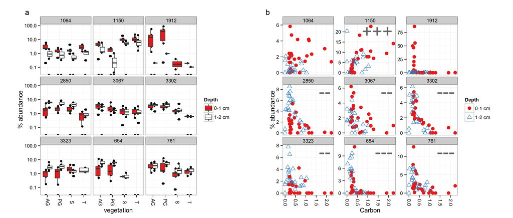

**Figure 7.** Relative abundance of the top 9 OTUs from the phyla (a) Bacteroidetes; (b) Cyanobacteria. Boxes represent the interquartile range (IQR), and error bars extend to the most extreme values within 1.5 * IQR of the box. Median values are shown as a line within the box and outliers are shown as black spots. Sample coding: AG=annual grass, PG=perennial grass, S=shrub, T=tree. Similar plots for other phyla are included in supplementary data.

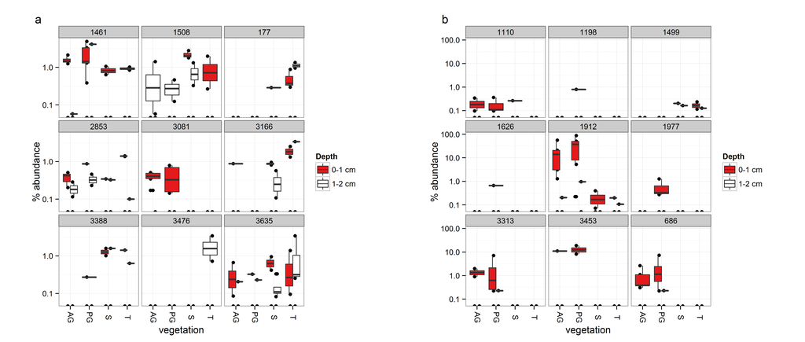

**Table 1.** Significance of factors depth, vegetation, and month on phylum abundance, as determined by Kruskal Wallis test. Significant effects were further tested by post-hoc analysis which is provided as supplementary material. Significance codes: *** < 0.001; ** < 0.01; * <0.05.

|  | Phylum | type_sig | zone_sig | month_sig |
| --- | --- | --- | --- | --- |
| Acidobacteria | Acidobacteria | ** | ** |  |
| Proteobacteria | Proteobacteria |  | *** |  |
| Bacteroidetes | Bacteroidetes | ** | *** |  |
| Firmicutes | Firmicutes | ** | . |  |
| Gemmatimonadetes | Gemmatimonadetes |  | *** |  |
| Cyanobacteria | Cyanobacteria | ** | ** |  |
| WPS.2 | WPS-2 |  | *** |  |
| Chloroflexi | Chloroflexi | * | *** |  |
| Actinobacteria | Actinobacteria | ** |  |  |

**Table 2.** Taxonomic classification of the most abundant 9 OTUs found in the study. Significance of depth, vegetation and month on OTU abundance is indicated by *** p < 0.001; ** p < 0.01; * p < 0.05, as determined by Kruskal Wallis test. Significant effects were further tested by post-hoc analyses which are provided as supplementary material.

|  | Phylum | Class | Order | Family | Genus | type_sig | zone_sig | month_sig |
| --- | --- | --- | --- | --- | --- | --- | --- | --- |
| 654 | Proteobacteria | Alphaproteobacteria | Rhodospirillales | Acetobacteraceae |  |  | *** |  |
| 761 | Acidobacteria | Solibacteres | Solibacterales | Solibacteraceae | Candidatus Solibacter | . | *** |  |
| 1064 | Proteobacteria | Alphaproteobacteria | Rhizobiales | Methylobacteriaceae | Methylobacterium | *** |  |  |
| 1150 | Proteobacteria | Alphaproteobacteria | Rhizobiales | Bradyrhizobiaceae | Balneimonas | * | *** |  |
| 1912 | Cyanobacteria | Oscillatoriophycideae | Oscillatoriales | Phormidiaceae | Phormidium | *** | * |  |
| 2850 | Proteobacteria | Alphaproteobacteria | Rhodospirillales | Rhodospirillaceae |  | *** | ** |  |
| 3067 | Proteobacteria | Alphaproteobacteria | Rhodospirillales | Acetobacteraceae |  |  | * |  |
| 3302 | Actinobacteria | Actinobacteria | Actinomycetales | Kineosporiaceae |  |  | *** |  |
| 3323 | Actinobacteria | Actinobacteria | Actinomycetales | Pseudonocardiaceae |  | *** |  |  |

**Table 3.** Taxonomic classification of the most abundant 9 Bacteroidetes and Cyanobacteria OTUs found in the study. Significance of depth, vegetation and month on OTU abundance is indicated by *** p < 0.001; ** p < 0.01; * p < 0.05, as determined by Kruskal Wallis test. Significant effects were further tested by post-hoc analyses which are provided as supplementary material.

|  | Phylum | Class | Order | Family | Genus | type_sig | zone_sig | month_sig |
| --- | --- | --- | --- | --- | --- | --- | --- | --- |
| 177 | Bacteroidetes | Sphingobacteriia | Sphingobacteriales | Chitinophagaceae |  |  | ** |  |
| 1461 | Bacteroidetes | Sphingobacteriia | Sphingobacteriales | Chitinophagaceae | Flavisolibacter | . |  |  |
| 1508 | Bacteroidetes | Sphingobacteriia | Sphingobacteriales | Chitinophagaceae | Flavisolibacter |  |  |  |
| 2853 | Bacteroidetes | Sphingobacteriia | Sphingobacteriales | Chitinophagaceae |  |  |  |  |
| 3081 | Bacteroidetes | Sphingobacteriia | Sphingobacteriales | Flexibacteraceae |  | ** | * |  |
| 3166 | Bacteroidetes | Sphingobacteriia | Sphingobacteriales | Chitinophagaceae | Segetibacter |  |  |  |
| 3388 | Bacteroidetes | Sphingobacteriia | Sphingobacteriales | Chitinophagaceae | Segetibacter |  |  |  |
| 3476 | Bacteroidetes | Sphingobacteriia | Sphingobacteriales | Chitinophagaceae |  |  |  |  |
| 3635 | Bacteroidetes | Sphingobacteriia | Sphingobacteriales | Chitinophagaceae |  |  |  |  |

|  | Phylum | Class | Order | Family | Genus | type_sig | zone_sig | month_sig |
| --- | --- | --- | --- | --- | --- | --- | --- | --- |
| 686 | Cyanobacteria | Oscillatoriophycideae |  |  |  | * | * |  |
| 1110 | Cyanobacteria | Oscillatoriophycideae |  |  |  | * |  |  |
| 1198 | Cyanobacteria | Oscillatoriophycideae |  |  |  |  |  |  |
| 1499 | Cyanobacteria | 4C0d-2 | MLE1-12 |  |  |  |  |  |
| 1626 | Cyanobacteria | Oscillatoriophycideae |  |  |  |  |  |  |
| 1912 | Cyanobacteria | Oscillatoriophycideae | Oscillatoriales | Phormidiaceae | Phormidium | ** | * |  |
| 1977 | Cyanobacteria | Oscillatoriophycideae |  |  |  |  | . |  |
| 3313 | Cyanobacteria | Oscillatoriophycideae |  |  |  | . | * |  |
| 3453 | Cyanobacteria | Oscillatoriophycideae | Oscillatoriales | Phormidiaceae |  |  |  |  |

## Supplementary data

This section includes supplementary plots, and statistical tests supporting statements made in the manuscript. Additional plots and tests can be found by following links in this document or exploring the results folders.

### Online Resource 3. ADONIS test for community differences with respect to vegetation zone, depth, and sampling month

This analysis was performed using adonis() function of the vegan package, which is described as follows:

> Analysis of variance using distance matrices - for partitioning distance matrices among sources of variation and fitting linear models (e.g., factors, polynomial regression) to distance matrices; uses a permutation test with pseudo-F ratios.

```
## The same test was run at each taxonomic rank.
```

```
##
##
## __ Phylum __
## ... procrustes: rmse 0.003268  max resid 0.01563
## ... procrustes: rmse 0.001116  max resid 0.006303
## *** Solution reached
##
##
## Call:
## adonis(formula = dist ~ zone * type + month, data = as(sample_data(expt.ord.taxrank),      "data.frame"))
##
## Terms added sequentially (first to last)
##
##           Df SumsOfSqs MeanSqs F.Model    R2 Pr(>F)
## zone       3      0.99   0.329    4.24 0.200  0.001 ***
## type       1      0.37   0.374    4.82 0.076  0.001 ***
## month      1      0.06   0.063    0.81 0.013  0.520
## zone:type  3      0.50   0.165    2.13 0.100  0.013 *
## Residuals 39      3.03   0.078         0.612
## Total     47      4.95                 1.000
## ---
## Signif. codes:  0 '***' 0.001 '**' 0.01 '*' 0.05 '.' 0.1 ' ' 1
##
##
## __ Class __
## ... procrustes: rmse 0.0004617  max resid 0.002663
## *** Solution reached
##
##
## Call:
## adonis(formula = dist ~ zone * type + month, data = as(sample_data(expt.ord.taxrank),      "data.frame"))
##
## Terms added sequentially (first to last)
##
##           Df SumsOfSqs MeanSqs F.Model    R2 Pr(>F)
## zone       3      1.30   0.432    5.01 0.225  0.001 ***
## type       1      0.45   0.446    5.17 0.078  0.001 ***
## month      1      0.11   0.113    1.31 0.020  0.238
## zone:type  3      0.53   0.177    2.05 0.092  0.008 **
## Residuals 39      3.36   0.086         0.585
```

[output cut: 79 more lines]

```
##
## Call:
## adonis(formula = dist ~ zone * type + month, data = as(sample_data(expt.ord.taxrank),      "data.frame"))
##
## Terms added sequentially (first to last)
##
##           Df SumsOfSqs MeanSqs F.Model    R2 Pr(>F)
## zone       3      3.48   1.158    4.88 0.227  0.001 ***
## type       1      1.17   1.172    4.94 0.076  0.001 ***
## month      1      0.34   0.342    1.44 0.022  0.096 .
## zone:type  3      1.08   0.360    1.52 0.070  0.014 *
## Residuals 39      9.26   0.237         0.604
## Total     47     15.33                 1.000
## ---
## Signif. codes:  0 '***' 0.001 '**' 0.01 '*' 0.05 '.' 0.1 ' ' 1
```

### Part of Online Resource 4. Statistical tests and extra plots supporting OTU abundance comparisons

Phylum results:

Phylum: OTU taxonomy and statistical results  
Directory containing stat tables for each test  
Phylum [top 9] zone plot  
Phylum [top 9] carbon plot  
Phylum [top 9] tree

Abundant OTUs results:

All: OTU taxonomy and statistical results  
Directory containing stat tables for each test  
All [top 9] zone plot  
All [top 9] carbon plot  
All [top 9] tree

Bacteroidetes results:

Bacteroidetes: OTU taxonomy and statistical results  
Directory containing stat tables for each test  
Bacteroidetes [top 9] zone plot  
Bacteroidetes [top 9] carbon plot  
Bacteroidetes [top 9] tree

Cyanobacteria results:

Cyanobacteria: OTU taxonomy and statistical results  
Directory containing stat tables for each test  
Cyanobacteria [top 9] zone plot  
Cyanobacteria [top 9] carbon plot  
Cyanobacteria [top 9] tree

### Soil chemistry supporting information

#### Carbon

```
##              zone    type   mean      sd
## 1    Annual_grass   crust 0.2950 0.04783
## 2    Annual_grass subsoil 0.2188 0.03728
## 3 Perennial_grass   crust 0.2250 0.03259
## 4 Perennial_grass subsoil 0.1480 0.06434
## 5           Shrub   crust 0.6547 0.17715
## 6           Shrub subsoil 0.4638 0.13543
## 7            Tree   crust 1.4600 0.48875
## 8            Tree subsoil 0.5785 0.45825
```

```
##      type   mean     sd
## 1   crust 0.6587 0.5573
## 2 subsoil 0.3523 0.2880
```

```
## Analysis of Variance Table
##
## Response: map.df$Carbon
##                      Df Sum Sq Mean Sq F value  Pr(>F)
## factor(map.df$zone)   3   5.16   1.722   19.56 4.3e-08 ***
## factor(map.df$type)   1   1.13   1.126   12.80 0.00089 ***
## factor(map.df$month)  1   0.19   0.190    2.16 0.14906
## Residuals            42   3.70   0.088
## ---
## Signif. codes:  0 '***' 0.001 '**' 0.01 '*' 0.05 '.' 0.1 ' ' 1
```

```
##   Tukey multiple comparisons of means
##     95% family-wise confidence level
##     factor levels have been ordered
##
## Fit: aov(formula = map.df$Carbon ~ factor(map.df$zone) + factor(map.df$type) + factor(map.df$month))
##
## $`factor(map.df$zone)`
##                                 diff      lwr    upr  p adj
## Annual_grass-Perennial_grass 0.07042 -0.25355 0.3944 0.9371
## Shrub-Perennial_grass        0.37275  0.04878 0.6967 0.0185
## Tree-Perennial_grass         0.83275  0.50878 1.1567 0.0000
## Shrub-Annual_grass           0.30233 -0.02164 0.6263 0.0751
## Tree-Annual_grass            0.76233  0.43836 1.0863 0.0000
## Tree-Shrub                   0.46000  0.13603 0.7840 0.0025
##
## $`factor(map.df$type)`
##                 diff    lwr    upr p adj
## crust-subsoil 0.3064 0.1335 0.4792 9e-04
##
## $`factor(map.df$month)`
##           diff      lwr    upr  p adj
## Nov-Mar 0.1259 -0.04695 0.2987 0.1491
```

#### C:N ratio

```
##              zone    type   mean    sd
## 1    Annual_grass   crust  7.968 2.110
## 2    Annual_grass subsoil  8.124 1.973
## 3 Perennial_grass   crust 10.403 4.356
## 4 Perennial_grass subsoil  7.581 2.216
## 5           Shrub   crust 10.320 1.147
## 6           Shrub subsoil  8.981 1.056
## 7            Tree   crust 11.452 2.375
## 8            Tree subsoil  6.546 5.041
```

```
##      type   mean    sd
## 1   crust 10.036 2.881
## 2 subsoil  7.808 2.914
```

```
## Analysis of Variance Table
##
## Response: map.df$CN
##                      Df Sum Sq Mean Sq F value  Pr(>F)
## factor(map.df$zone)   3   15.7     5.2    0.78 0.50985
## factor(map.df$type)   1   59.6    59.6    8.91 0.00471 **
## factor(map.df$month)  1   89.9    89.9   13.45 0.00068 ***
## Residuals            42  280.7     6.7
## ---
## Signif. codes:  0 '***' 0.001 '**' 0.01 '*' 0.05 '.' 0.1 ' ' 1
```

```
##   Tukey multiple comparisons of means
##     95% family-wise confidence level
##     factor levels have been ordered
##
## Fit: aov(formula = map.df$CN ~ factor(map.df$zone) + factor(map.df$type) + factor(map.df$month))
##
## $`factor(map.df$zone)`
##                                  diff    lwr   upr  p adj
## Perennial_grass-Annual_grass 0.945948 -1.877 3.769 0.8068
## Tree-Annual_grass            0.952897 -1.870 3.776 0.8033
## Shrub-Annual_grass           1.604547 -1.218 4.428 0.4347
## Tree-Perennial_grass         0.006949 -2.816 2.830 1.0000
## Shrub-Perennial_grass        0.658599 -2.164 3.482 0.9238
## Shrub-Tree                   0.651650 -2.171 3.475 0.9259
##
## $`factor(map.df$type)`
##                diff    lwr   upr  p adj
## crust-subsoil 2.228 0.7219 3.734 0.0047
##
## $`factor(map.df$month)`
##          diff   lwr   upr p adj
## Nov-Mar 2.737 1.231 4.243 7e-04
```

#### Correlation of C and N

```
##
## Call:
## lm(formula = map.df$Nitrogen ~ map.df$Carbon)
##
## Residuals:
##       Min        1Q    Median        3Q       Max
## -0.029632 -0.007291  0.000414  0.005297  0.027902
##
## Coefficients:
##               Estimate Std. Error t value Pr(>|t|)
## (Intercept)    0.01253    0.00240    5.23  4.1e-06 ***
## map.df$Carbon  0.07702    0.00351   21.97  < 2e-16 ***
## ---
## Signif. codes:  0 '***' 0.001 '**' 0.01 '*' 0.05 '.' 0.1 ' ' 1
##
## Residual standard error: 0.0112 on 46 degrees of freedom
## Multiple R-squared:  0.913,  Adjusted R-squared:  0.911
## F-statistic:  483 on 1 and 46 DF,  p-value: <2e-16
```

### Richness and diversity supporting information

Check significance of correlation between richness/diversity and carbon (Spearman):

```
## Chao1
##  Spearman's rank correlation rho
##
## data:  carbon_richness$value and carbon_richness$Carbon
## S = 9258, p-value = 0.0003211
## alternative hypothesis: true rho is not equal to 0
## sample estimates:
##    rho
## 0.4975
##
## Shannon
##  Spearman's rank correlation rho
##
## data:  carbon_richness$value and carbon_richness$Carbon
## S = 9256, p-value = 0.00032
## alternative hypothesis: true rho is not equal to 0
## sample estimates:
##    rho
## 0.4976
```

Check effect of depth and vegetation zone on richness/diversity (Kruskal-Wallis):

```
##
##  Kruskal-Wallis rank sum test
##
## data:  rich.plus$Shannon by rich.plus$type
## Kruskal-Wallis chi-squared = 2.929, df = 1, p-value = 0.087
```

```
##
##  Kruskal-Wallis rank sum test
##
## data:  rich.plus$Shannon by rich.plus$zone_code
## Kruskal-Wallis chi-squared = 22.91, df = 3, p-value = 4.222e-05
```

```
##
##  Kruskal-Wallis rank sum test
##
## data:  rich.plus$Chao1 by rich.plus$type
## Kruskal-Wallis chi-squared = 0.5208, df = 1, p-value = 0.4705
```

```
##
##  Kruskal-Wallis rank sum test
##
## data:  rich.plus$Chao1 by rich.plus$zone_code
## Kruskal-Wallis chi-squared = 17.08, df = 3, p-value = 0.0006791
```

```
## Post-hoc test - Shannon diversity
```

```
## Multiple comparison test after Kruskal-Wallis
## p.value: 0.05
## Comparisons
##       obs.dif critical.dif difference
## AG-PG   4.417        15.08      FALSE
## AG-S   20.000        15.08       TRUE
## AG-T   12.083        15.08      FALSE
## PG-S   24.417        15.08       TRUE
## PG-T   16.500        15.08       TRUE
## S-T     7.917        15.08      FALSE
```

```
## Post-hoc test - Chao1 richness
```

```
## Multiple comparison test after Kruskal-Wallis
## p.value: 0.05
## Comparisons
##       obs.dif critical.dif difference
## AG-PG  0.6667        15.08      FALSE
## AG-S  19.2500        15.08       TRUE
## AG-T  11.7500        15.08      FALSE
## PG-S  19.9167        15.08       TRUE
## PG-T  12.4167        15.08      FALSE
## S-T    7.5000        15.08      FALSE
```

### Online Resource 2. Ordination supplementary information

Constrained and Unconstrained comparison, and scree plots. The constrained ordination shown here is exactly the same as the one used for the main figure above.

**Constrained and unconstrained ordinations with scree plots.**

[figure not shown]

### OTUs supplementary

**Part of Online resource 4.** Relative abundance of Proteobacterial classes, by (a) site and (b) soil carbon content. Boxes represent the interquartile range (IQR), and error bars extend to the most extreme values within 1.5 * IQR of the box. Median values are shown as a line within the box and outliers are shown as black spots. Significance and direction of correlation between OTU abundance and soil carbon is indicated by + or - (determined by Spearman test). Significance codes for positive correlation: +++ < 0.001; ++ < 0.01; + <0.05. Sample coding: AG=annual grass, PG=perennial grass, S=shrub, T=tree.

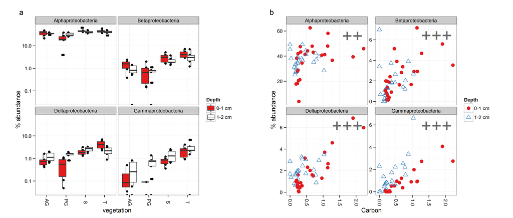

**Top 16 phyla**

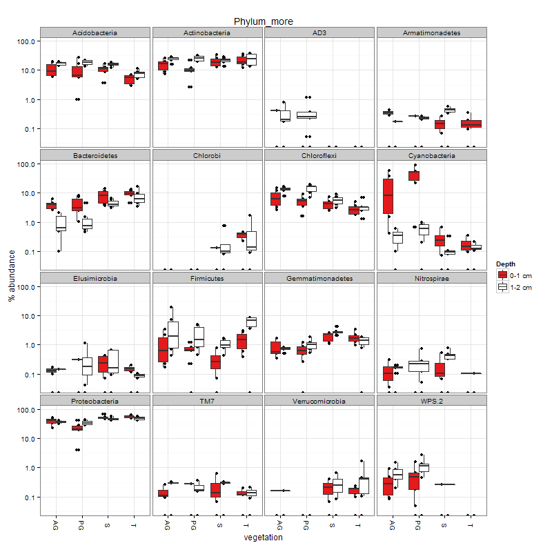

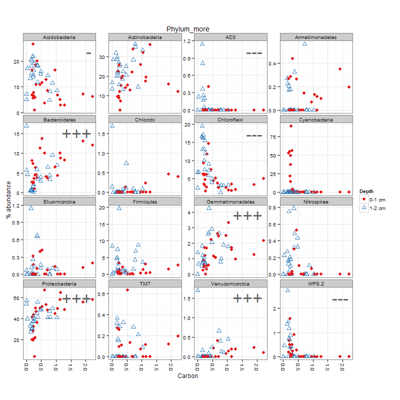

**Each Phylum in turn:** See plots in folder figures_extra and results in statistics

### Calculations for manuscript text

```r
print(calcs_for_manuscript)
```

```
## $`total phyla`
## [1] 28
##
## $`top 9 phyla sum`
## [1] 99.08
##
## $`top 16 phyla sum`
## [1] 99.78
##
## $`total actinobacteria`
## [1] 20.78
##
## $`total proteobacteria`
## [1] 42.02
##
## $`top 9 OTUs sum`
## [1] 26.75
##
## $`total bacteroidetes`
## [1] 5.092
##
## $`total cyanobacteria`
## [1] 8.14
##
## $`Chloroflexi n OTUs`
## [1] 408
##
## $`Chloroflexi top 9`
## [1] 2.65
##
## $`Proteobacteria n OTUs`
## [1] 935
##
## $`Proteobacteria top 9`
## [1] 17.87
##
## $`Bacteroidetes n OTUs`
## [1] 297
##
## $`Bacteroidetes top 9`
```

[output cut: 139 more lines]

```
##
## $`WPS-2 n OTUs`
## [1] 5
##
## $`WPS-2 top 9`
## [1] 0.3315
##
## $`BRC1 n OTUs`
## [1] 1
##
## $`BRC1 top 9`
## [1] 0.001701
##
## $`total for top 9 of each phylum`
## [1] 50.34
```